# Guion de Prácticas de la parte de *Introducción a la Estadística* del curso *Introducción a la Ciencia de Datos*

## 1.3 Test para comparar resultados de varios clasificadores

En este apartado vamos a comparar el comportamiento de varios clasificadores. Puede descargar los datos desde el siguiente enlace:

[Classification Algorithms](https://decsai.ugr.es/jccubero/Master/ClassificationAlgorithms.omv)

obtendrá una vista como la siguiente:

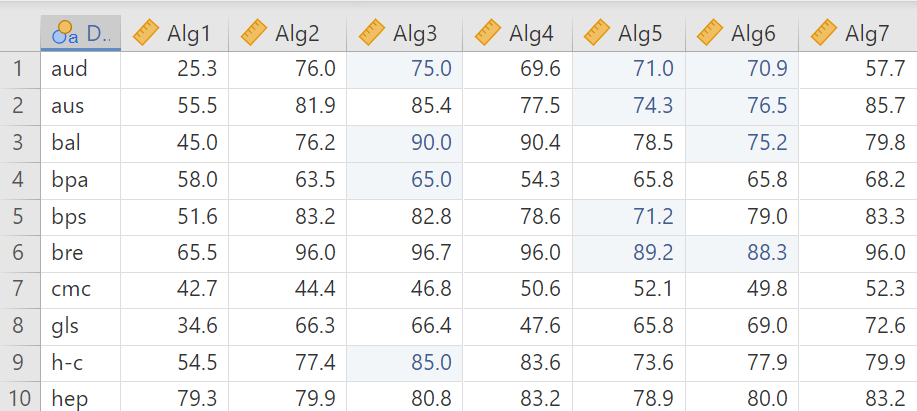

El método que vamos a seguir para la comparación es el siguiente: tenemos 7 algoritmos y vamos a medir el porcentaje de acierto en una treintena de conjuntos de datos. Dicho porcentaje ha podido obtenerse, por ejemplo, como una media de los porcentajes de acierto después de una validación cruzada. Queremos ver si podemos considerar que los siete clasificadores tienen una tasa de acierto similar o si hay alguno que no. En este ejemplo, podemos considerar que cada uno de los conjuntos de datos utilizados son los *sujetos* del estudio, a los que se les ha aplicado una serie de *medidas repetidas* al evaluar el comportamiento de distintos algoritmos sobre cada uno de ellos. Estamos por tanto en un caso de k muestras dependientes (o de medidas repetidas)

Veamos qué requisitos se cumplen para aplicar un test u otro:

- Podemos aceptar que las filas (los datasets) se han elegido de forma aleatoria por lo que son independientes entre sí.
- Si analizamos los histogramas de las columnas (Exploration/Descriptives/Histogram) vemos que ninguno se asemeja a una normal. Además, muchos de ellos presentan varios *picos* lo que supone una desviación importante del requisito de normalidad, por lo que debemos usar un test no paramétrico. Si lo desea, puede ejecutar desde Jamovi un Anova paramétrico y ver que el gráfico QQ de los residuos nos dice que, tal y como era de esperar, éstos no se ajustan a una distribución normal. El test a aplicar, por tanto, es un test no paramétrico. Así pues aplicaremos el test de Friedman (no paramétrico de medidas repetidas)
- Una vez que hemos determinado que el test a aplicar es el de Friedman, necesitamos ver si las distribuciones de los grupos (las columnas) son similares. Tal y como hemos apreciado anteriormente, no es así ya que los histogramas eran muy distintos entre sí. Por lo tanto, el test de Friedman es un test de dominancia estocástica y no sobre las medianas.

Si aplicamos el test de Friedman y el post hoc correspondiente, obtenemos los siguientes grupos:

{Alg1, {Alg2, Alg4, Alg5, Alg6}, {Alg3, Alg7}}

Si observamos las tasas de acierto, vemos que Alg1 es un algoritmo muy malo, mientras que Alg3 y Alg7 son mejores que el resto, pero indistiguibles entre sí. En resumen, podemos afirmar que los algoritmos 3 y 7 presentan los mejores resultados, dominando estocásticamente sobre el resto de algoritmos.

Ejecute el Anova paramétrico y observe que en el post hoc sólo obtiene que el algoritmo 1 es distinto al resto. Este es un ejemplo en el que si no se verifican los requisitos del Anova paramétrico no debemos ejecutarlo ya que, en el caso de hacerlo, podríamos obtener (erróneamente) unas conclusiones que no nos permitiesen rechazar la igualdad entre algunos grupos. En igualdad de condiciones, el test de Friedman tiene menos potencia que el Anova paramétrico, pero si no se dan dichas condiciones, simplemente no debemos ejecutar el Anova.

Finalmente, comentemos que en la sección de R, realizaremos un análisis similar pero suprimiremos el Algoritmo 1 ya que presenta sistemáticamente resultados peores y no tiene mucho sentido incluirlo en la comparación. Tenga en cuenta que el test omnibus (el conjunto) obviamente dará significativo y queremos evitar esta situación. Si no incluimos el algoritmo 1 y el test omnibus da significativo, tendremos la garantía de que es al menos uno de los algoritmos *decentes* el que tiene un comportamiento distinto al resto.

# 2 Tests de Hipótesis con R

Esta parte es de ampliación, aunque es muy recomendable ya que hay ciertos tests que no se pueden lanzar desde el entorno gráfico de Jamovi. Por ejemplo, por ahora, Jamovi no permite realizar un post-hoc en el que se fije un grupo y por tanto la penalización del nivel de significación sea más suave al disminuir el número de comparaciones múltiples. Esto es de especial importancia cuando se va a comparar el resultado de un clasificador nuevo que hayamos desarrollado con otros clasificadores existentes en la literatura. En esta caso, no queremos comparar los tests ya existentes entre sí sino únicamente nuestro nuevo test (será el control) con el resto.

Muchos de los tests que vamos a ver están directamente accesibles desde R, mientras que otros están en paquetes que habrá que instalar. La lista de paquetes a instalar (y las librerías correspondientes que habrá que cargar en cada sesión) se pueden encontrar en el siguiente enlace:

https://decsai.ugr.es/jccubero/Master/IntrodEstadLibrerias.R

Uno de los paquetes que vamos a usar es `rstatx`. Proporciona distintos *wrappers* que permiten usar los tests más conocidos en flujos de ejecución al estilo de `tidyverse`. También proporciona herramientas para mostrar gráficos de cajas con los p-values obtenidos con un post hoc. Para facilitar su uso, puede utilizar las funciones definidas en el siguiente enlace (© JC Cubero):

https://decsai.ugr.es/jccubero/Master/IntrodEstadFunciones.R

En el anterior paquete puede encontrar las siguientes funciones:

```r
GraficoCajas = function (datos, variable_depend, variable_factor, titulo = "")
```

Muestra un diagrama de cajas conjunto de una variable dependiente agrupada por los valores de la variable factor.

```r
GraficoCajasTest = function (datos, variable_depend, variable_factor,
                            es_param, es_mr, test)
```

Muestra un diagrama de cajas conjunto de una variable dependiente agrupada por los valores de la variable factor, incluyendo los resultados de un test del paquete `rstatix`. Los parámetros `es_param` (es paramétrico) y `es_mr` (es de medidas repetidas) son lógicos y se usan para construir el título del gráfico.

```r
GraficoCajasPost = function(datos, variable_depend, variable_factor,
                            es_param, es_mr, test,
                            control = "", estrellas = FALSE)
```

Realiza lo mismo que la anterior función para un test post hoc, por lo que añade los p-values de las comparaciones múltiples. Si hay un grupo de control se pasa en el parámetro `control`. El parámetro `estrellas` indica si se quieren imprimir asteriscos en vez de los valores numéricos de los p-values

Para ejecutar los distintos tests, puede descargar los siguientes conjuntos de datos:

- [Datos de empleados (RData)](https://decsai.ugr.es/jccubero/Master/DatosEmpleados.RData) contiene el conjunto de datos con nombre `DatosEmpleados`
- [Cholesterol (RData)](https://decsai.ugr.es/jccubero/Master/Cholesterol.RData) contiene el conjunto de datos con nombre `Colesterol`

Al igual que en la la sección tests con Jamovi suponemos que las filas son **independientes** entre sí y que las muestras son independientes dentro de cada grupo (también entre los distintos grupos en el caso de muestras independientes).

## 2.1 Tests para muestras independientes

Vamos a cargar el dataset `DatosEmpleados` y establecemos los nombres de las variables con las que vamos a trabajar. También convertimos a factor la columna de la variable de agrupación ya que algunos tests como `aov` así lo requieren. Lo hacemos con la función `as.factor`:

```r
load("DatosEmpleados.RData")
datos = DatosEmpleados
v.depend = "salario"
v.factor.2.valores = "sexo"
indice.col.factor.2valores = which(colnames(datos) == v.factor.2.valores)
datos[,indice.col.factor.2valores] = as.factor(as.data.frame(datos)[,indice.col.factor.2valores])
```

```r
head(datos)
##   Id   sexo   fechnac educ         catlab salario salini tiempemp expprev minoría
## 1  1 Hombre  2/3/1952   15      Directivo   57000  27000       98     144      No
## 2  2 Hombre 5/23/1958   16 Administrativo   40200  18750       98      36      No
## 3  3  Mujer 7/26/1929   12 Administrativo   21450  12000       98     381      No
## 4  4  Mujer 4/15/1947    8 Administrativo   21900  13200       98     190      No
## 5  5 Hombre  2/9/1955   15 Administrativo   45000  21000       98     138      No
## 6  6 Hombre 8/22/1958   15 Administrativo   32100  13500       98      67      No
```

Algunos tests usan *fórmulas* para especificar la variable dependiente y la de agrupación. Por ejemplo, si queremos realizar un Anova del salario sobre el sexo, usaríamos la fórmula siguiente:

```r
salario ~ sexo
```

Para no tener que repetir dicha expresión, la guardamos en una variable `formula` aplicando la función `as.formula`:

```r
formula.t.test = as.formula(paste0(v.depend, "~", v.factor.2.valores))  # 2 muestras independientes
```

```r
formula.t.test
## salario ~ sexo
```

### 2.1.1 Prueba para dos muestras independientes (test paramétrico)

Trabajamos sobre `DatosEmpleados` con las variables `v.depend` (`salario`) y `v.factor.2.valores` (`sexo`). En primer lugar, construimos un gráfico con los diagramas de cajas:

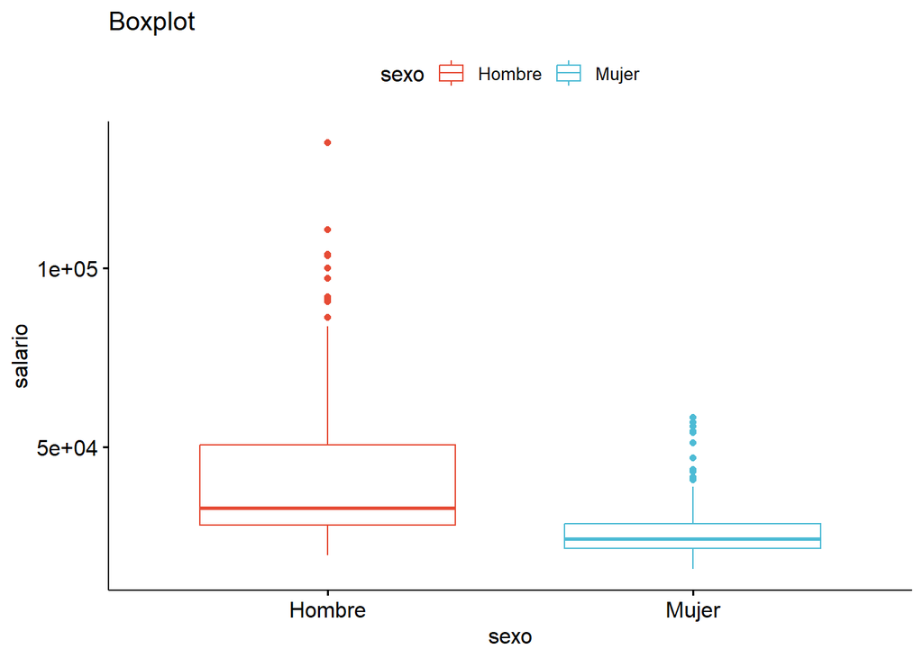

```r
GraficoCajas(datos, v.depend, v.factor.2.valores, "Boxplot")
```

El gráfico nos muestra que hay mucha menos varianza en el grupo de las mujeres que en el de hombres. Para confirmarlo podemos llamar a la función `levene_test`. El test de **Levene** sale, claramente, significativo, por lo que rechazamos que las varianzas sean iguales:

```r
test_homoc_levene = levene_test(formula.t.test, data = datos)
test_homoc_levene
## # A tibble: 1 × 4
##     df1   df2 statistic        p
##   <int> <int>     <dbl>    <dbl>
## 1     1   472      51.6 2.67e-12
```

Como las varianzas son distintas, lanzamos el test de **Welch** llamando a la correspondiente función de `rstatix` y mostramos el resultado con la función `GraficoCajasTest`.

```r
test_welch = welch_anova_test(formula = formula.t.test, data = datos)
```

`test_welch` contiene información sobre el valor de estadístico del test, los grados de libertad, el p-value, etc. Para mostrar este último, basta acceder al valor `p`:

```r
test_welch$p
## [1] 8.3e-27
```

O directamente lo vemos en la gráfica correspondiente (en vez de mostrar el valor exacto, simplemente nos dice que es menor que 0.0001):

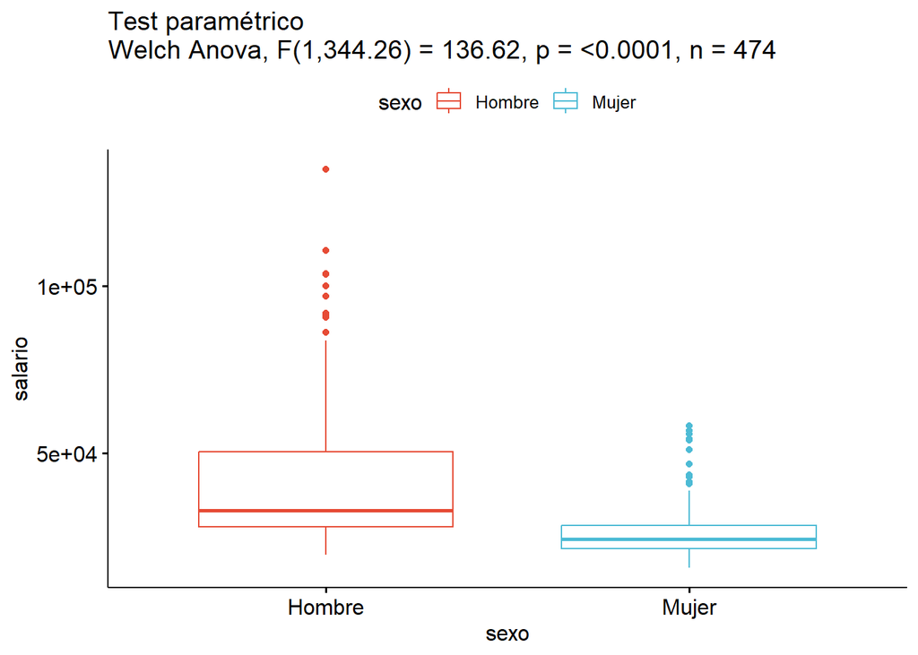

```r
GraficoCajasTest(datos, v.depend, v.factor.2.valores,
                 es_param = TRUE, es_mr = FALSE, test_welch)
```

Aunque el test de Welch es robusto a la desviaciones de la normalidad de los residuos, debemos analizarlos para tener una garantía estadística. Para extraer los residuos de un test realizado con `rstatix`, debemos utilizar la función `anova_test` que veremos posteriormente (es la generalización de la función `t_test` cuando hay más de dos grupos) Definimos nuestra propia función `Residuos` para realizar dicha tarea:

```r
Residuos = function (data, var.depend, var.factor){
  formula.anova = as.formula(paste0(var.depend, "~", var.factor))  # k>2 muestras independientes
  test_anova = anova_test(formula = formula.anova, data = data)
  modelo_test = attr(test_anova, "args")$model
  residuals(modelo_test)
}
```

```r
test_anova_2muestras = anova_test(formula.t.test, data = datos)
residuos_test_anova_2muestras = Residuos(datos, v.depend, v.factor.2.valores)
```

Para ver si siguen una distribución normal, podemos lanzar el test de **Shapiro** aunque normalmente es suficiente con que el gráfico QQ no muestre una desviación acusada (usamos las funciones `shapiro.test` y `ggqqplot`)

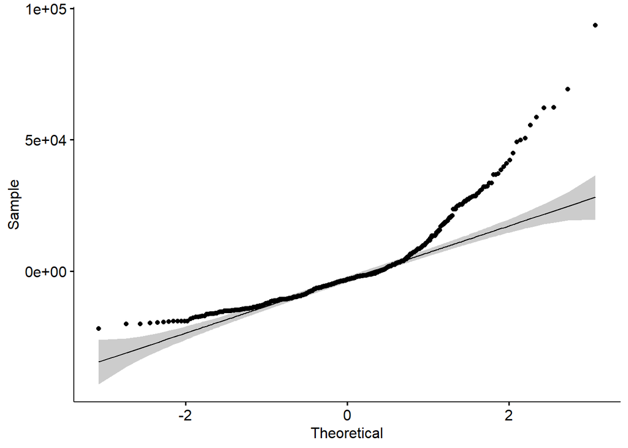

```r
test_normalidad_residuos = shapiro.test(x = residuos_test_anova_2muestras)
test_normalidad_residuos
##
##  Shapiro-Wilk normality test
##
## data:  residuos_test_anova_2muestras
## W = 0.83621, p-value < 2.2e-16
ggqqplot(residuos_test_anova_2muestras)
```

Podemos apreciar (ya lo habíamos visto con Jamovi) que no se cumple la hipótesis de normalidad de los residuos, por lo que optamos por aplicar un test no paramétrico. Lo hacemos a continuación.

### 2.1.2 Test no paramétrico para comparar dos muestras independientes

Para aplicar el test de **Mann-Whitney** llamamos a la función `wilcox_test` de `rstatix` y construimos la gráfica llamando a la función `GraficoCajasTest`:

[figure not shown]

```r
test_mann_whitney = wilcox_test(data = datos, formula = formula.t.test)
GraficoCajasTest(datos, v.depend, v.factor.2.valores,
                 es_param = TRUE, es_mr = FALSE, test_mann_whitney)
```

Recordemos que es un test de dominancia estocástica. Si los grupos presentan distribuciones similares, también será un test sobre las medianas, pero ya habíamos visto que las varianzas del salario eran distintas en el grupo de hombres y en el grupo de mujeres, por lo que las distribuciones no son similares. Por tanto, no podemos afirmar que sea un test sobre las medianas y concluimos que el salario de los hombres es una variable tal que si elegimos al azar un hombre y una mujer es más probable que el salario del primero sea mayor que el de la mujer.

### 2.1.3 Anova para k muestras independientes (test paramétrico)

#### 2.1.3.1 Test conjunto (omnibus)

Trabajamos sobre `DatosEmpleados` con las variables `salario` y `catlab`. En primer lugar, establecemos los nombres de las variables y de la fórmula:

```r
v.factor = "catlab"
indice.col.factor = which(colnames(datos) == v.factor)
datos[,indice.col.factor] = as.factor(as.data.frame(datos)[,indice.col.factor])
formula.anova = as.formula(paste0(v.depend, "~", v.factor))  # k>2 muestras independientes
```

Para comprobar la normalidad de los residuos, llamamos a la función `Residuos` que habíamos definido previamente:

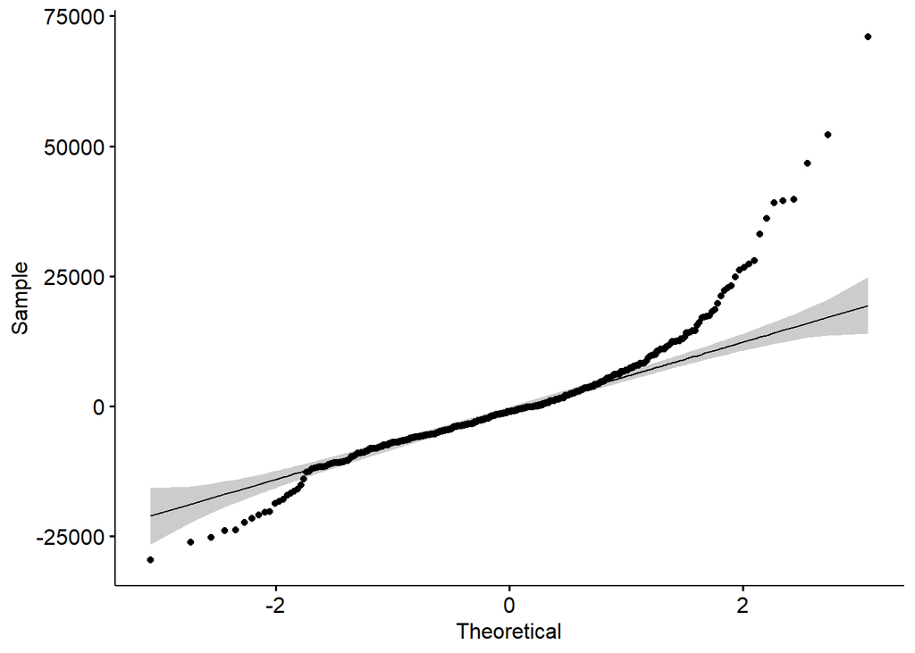

```r
residuos.anova = Residuos (data = datos, v.depend, v.factor)
ggqqplot(residuos.anova)
```

Construimos un gráfico con los diagramas de cajas y aplicamos el test de Levene:

```r
test_homoc_levene = levene_test(formula.anova, data = datos)
test_homoc_levene
## # A tibble: 1 × 4
##     df1   df2 statistic        p
##   <int> <int>     <dbl>    <dbl>
## 1     2   471      51.2 7.65e-21
```

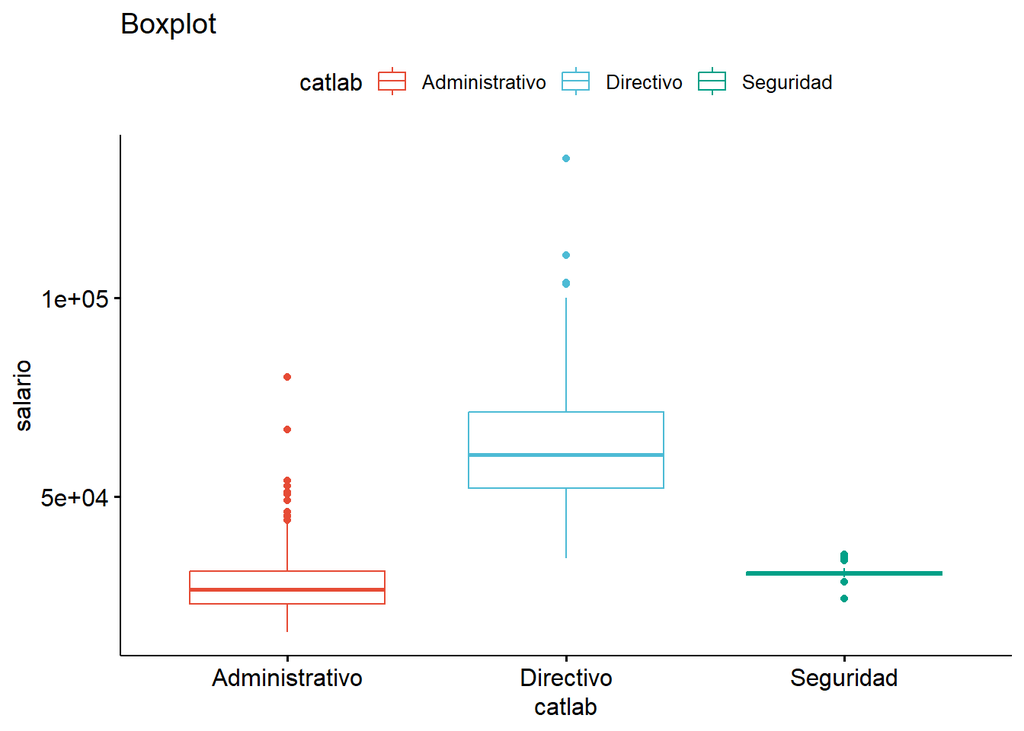

```r
GraficoCajas(datos, v.depend, v.factor, "Boxplot")
```

El test de Levene confirma lo que vemos en el diagrama de cajas y es que las varianzas son distintas en cada grupo. Aplicamos por tanto el test de Welch y nos ha de salir lo siguiente:

```r
# COMPLETAR
```

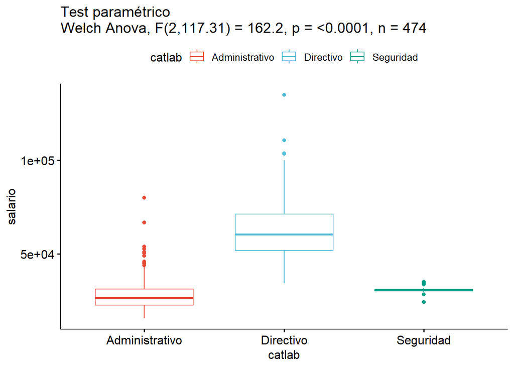

El test es significativo y por tanto podemos asegurar que hay al menos una categoría laboral con un salario distinto al resto. Procedemos al post-hoc:

#### 2.1.3.2 Post hoc

##### Post hoc específico

Como los grupos según la categoría laboral tienen varianzas distintaS, Lanzamos las comparaciones múltiples con el post-hoc *específico* de **Games-Howell** llamando a la función `games_howell_test` de `rstatix` con los parámetros habituales de la fórmula y el conjunto de datos. Llamamos también a la función `GraficoCajasPost` y vemos que el test rechaza la igualdad entre las medias de todos los grupos:

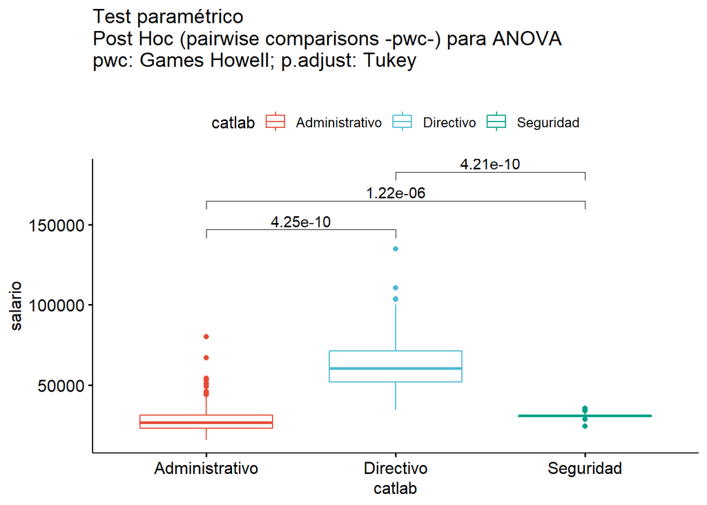

```r
post_games_howell <- games_howell_test(datos, formula.anova)
GraficoCajasPost(datos, v.depend, v.factor,
                 es_param = TRUE , es_mr = FALSE, post_games_howell)
```

Tal y como vimos en la sección de Jamovi, si hubiésemos utilizado el test de Tukey HSD como post hoc, no podríamos haber rechazado la igualdad entre Administrativos y Seguridad ya que es test de Tukey sólo ha de aplicarse cuando todos los grupos tienen la misma varianza y en este caso no se cumple. Para comprobarlo, lanzamos el test con la función `tukey_hsd` de `rstatix`:

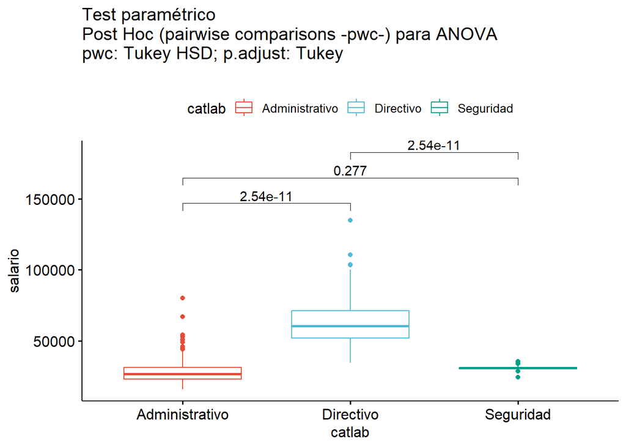

```r
post_tukey <- tukey_hsd(datos, formula.anova)
GraficoCajasPost(datos, v.depend, v.factor,
                 es_param = TRUE , es_mr = FALSE, post_tukey)
```

##### Post hoc genérico

Vamos a ejecutar ahora las comparaciones múltiples usando para cada comparación un *test generico* y aplicando una penalización. En este caso, usaríamos el test de **Welch** para realizar cada una de las comparaciones entre las medias de dos grupos. Recordemos que Jamovi (apartado Anova para k muestras independientes (test paramétrico)) usaba en el test genérico una varianza *agregada* pero no era lo recomendable al tener los grupos varianzas diferentes. Por tanto, nuestro propósito es lanzar las comparaciones múltiples, usando como test base para cada comparación el test de Welch (no usando la varianza agregada) y penalizando con Holm. Para ello, llamamos a la función `pairwise_t_test` de `rstatix` (el parámetro `pool.sd` es el de la varianza agregada y es `TRUE` por defecto por lo que lo tenemos que cambiar)

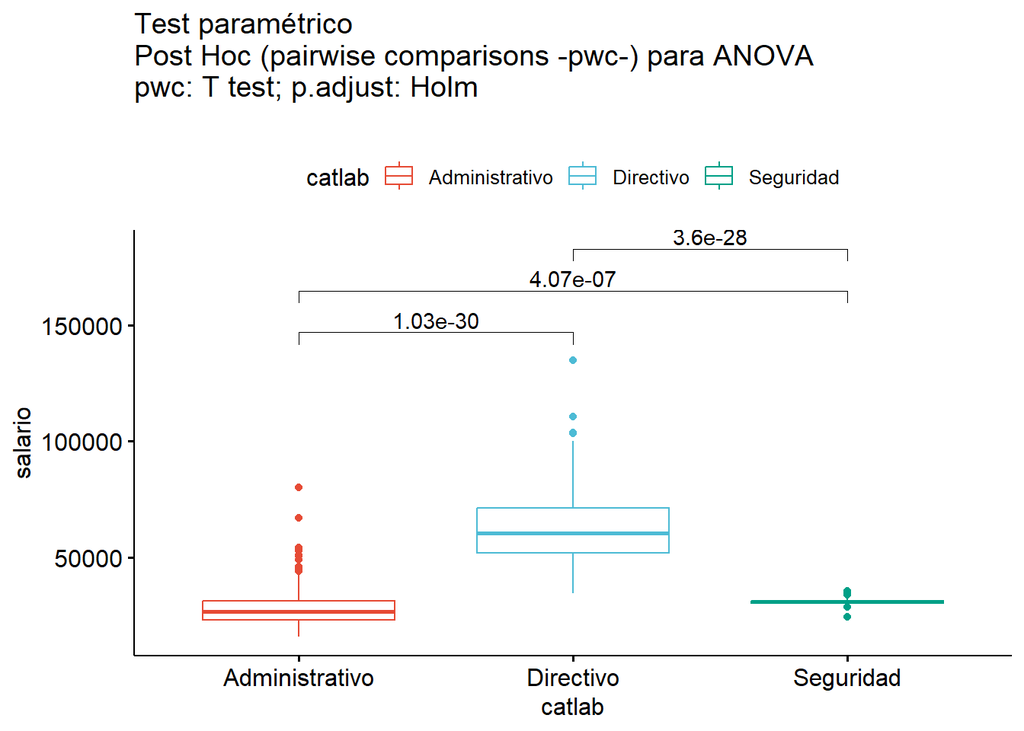

```r
post_pw_t_test <- pairwise_t_test (formula.anova, data = datos,
                                   pool.sd = FALSE)
GraficoCajasPost(datos, v.depend, v.factor ,
                 es_param = TRUE , es_mr = FALSE, post_pw_t_test)
```

Si queremos obtener el mismo resultado que Jamovi (algo no recomendado en este caso por lo que hemos comentado anteriormente) habríamos ejecutado lo siguiente:

```r
post_pw_t_test_JAMOVI <- pairwise_t_test (formula.anova, data = datos,
                                   pool.sd = TRUE)
post_pw_t_test_JAMOVI
## # A tibble: 3 × 9
##   .y.     group1         group2       n1    n2         p p.signif     p.adj p.adj.signif
## * <chr>   <chr>          <chr>     <int> <int>     <dbl> <chr>        <dbl> <chr>
## 1 salario Administrativo Directivo   363    84 9.61e-109 ****     2.88e-108 ****
## 2 salario Administrativo Seguridad   363    27 1.26e-  1 ns       1.26e-  1 ns
## 3 salario Directivo      Seguridad    84    27 1.27e- 40 ****     2.54e- 40 ****
```

*Nota*. También podríamos haber llamado a la función `t_test` de `rstatix` (la que usábamos para comparar **dos** muestras) con el parámetro `var.equal = FALSE` (utilizará la varianza no agregada) y `p.adjust.method="holm"` ya que si le pasamos a `t_test` como parámetro una fórmula que tiene un factor con más de dos niveles, automáticamente realiza las comparaciones múltiples llamando a `pairwise_t_test`

##### Post hoc con control

Si deseamos fijar un grupo de control y así disminuir la penalización para corregir el error FWER, podemos lanzar el test específico de **Dunnett** disponible en el paquete `DescTools`. También podemos usar el mismo test genérico usando la función `pairwise_t_test` pasándolo el grupo de control en el parámetro `ref.group`

### 2.1.4 Anova para k muestras independientes (test no paramétrico)

#### 2.1.4.1 Test conjunto (omnibus)

Recordemos que al no cumplirse la hipótesis de normalidad de los residuos, es conveniente aplicar un test no paramétrico. Para ejecutar el test de **Kruskal-Wallis** llamamos a la función `kruskal_test` de `rstatix` en la forma habitual con la fórmula y los datos. Llamamos también a la función `GraficoCajasTest`. Nos debe salir lo siguiente:

```r
# COMPLETAR
```

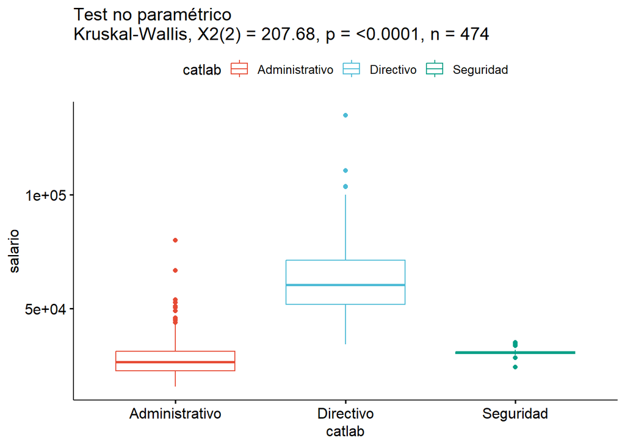

Recordemos que el test de Kruskal-Wallis es un test de dominancia estocástica. Si los grupos hubiesen presentado distribuciones similares, también sería un test sobre las medianas. Sin embargo, hemos visto que las varianzas son distintas en cada grupo por lo que no tienen distribuciones similares. En cualquier caso, si queremos ver las distribuciones de cada grupo, podemos usar la función `ggdensity` de la siguiente forma:

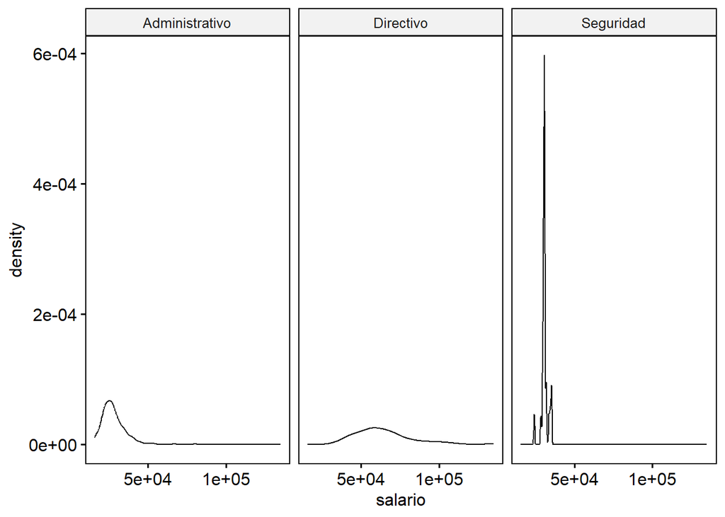

```r
ggdensity(as.data.frame(datos), v.depend, facet.by = v.factor)
```

#### 2.1.4.2 Post hoc

##### Post hoc específico

`rstatix` proporciona el test específico de **Dunn** en vez del test de **Dwass-Steel-Critchlow-Fligner** que veíamos con Jamovi. Se ejecuta en la forma habitual:

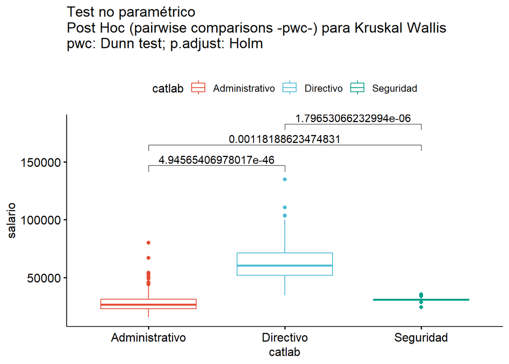

```r
post_kw_dunn = dunn_test(formula.anova, data = datos)
GraficoCajasPost(datos, v.depend, v.factor,
                 es_param = FALSE , es_mr = FALSE, post_kw_dunn)
```

Un test específico aún mejor que el de Dunn es el test de **Conover** incluido en el paquete `PMCMRPlus` a través de la función `kwAllPairsConoverTest`. En este test, hay que especificar el tipo de penalización a realizar. Usamos la de **Holm**:

```r
post_kw_conover = kwAllPairsConoverTest(formula.anova, data = datos,
                                        p.adjust.method = "holm")
post_kw_conover
##           Administrativo Directivo
## Directivo < 2e-16        -
## Seguridad 1.9e-05        3.1e-10
```

Podemos apreciar que el test de Conover es capaz de rechazar la igualdad entre Administrativos y Seguridad con más fuerza que el de Dunn.

*Nota*. Si desea lanzar manualmente el test de **Dwass-Steel-Critchlow-Fligner**, puede recurrir a la función `dscfAllPairsTest` en el paquete `PMCMRPlus`. También puede ejecutar el test de **Nemenyi** a través de la función `kwAllPairsNemenyiTest` del mismo paquete.

*Nota*. EL paquete `PMCMRPlus` contiene muchos tests para realizar el post hoc no paramétrico. Sin embargo, los tests no son compatibles con `rstatix`, por lo que no podremos mostrar los resultados con la función `GraficoCajasPost`.

##### Post hoc genérico

Para ejecutar las comparaciones múltiples usando un test genérico con una penalización del nivel de significación usamos la misma función `wilcox_test` que usábamos para ejecutar el test de Mann-Whitney en el caso no paramétrico de 2 muestras independientes. Si la variable factor de la fórmula pasada como parámetro contiene más de un grupo, automáticamente se realizan las comparaciones múltiples:

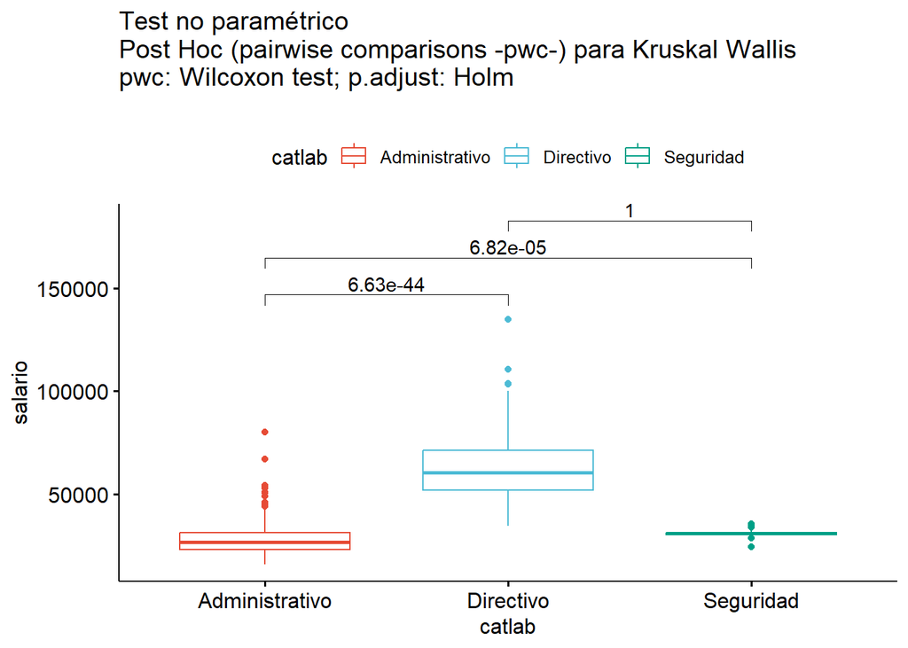

```r
post_kw_wilc = wilcox_test(formula.anova, data = datos, alternative = "l")
GraficoCajasPost(datos, v.depend, v.factor,
                 es_param = FALSE, es_mr = FALSE, post_kw_wilc)
```

##### Post hoc con control

Si queremos fijar un *grupo de control*, podemos usar el test específico de **Conover** (usando la función `kwManyOneConoverTest` de `PMCMRPlus`) o bien el test genérico de **Wilcoxon** usando la función anterior `wilcox_test` y el parámetro `ref.group`.

## 2.2 Tests para muestras dependientes o de medidas repetidas

Tal y como vimos en el apartado de Jamovi, asumimos que las filas dentro de cada grupo son independientes entre sí. Obviamente, las filas de grupos distintos no son independientes entre sí.

Usaremos el sufijo `mr` (medidas repetidas) en los nombres de las variables y objetos que creemos.

### 2.2.1 Prueba T (t-Student) para dos muestras pareadas (medidas repetidas)

- test: ¿Puede considerarse que la diferencia entre las medias del salario actual y el salario inicial es cero?

Para lanzar el test T para muestras pareadas usando directamente el conjunto de datos original, podemos usar la función `t.test` (observe que no es la función `t_test` de `rstatix`) Le pasamos como parámetro los dos vectores correspondientes a las dos muestras pareadas (salario inicial y salario final) y, muy importante, el parámetro **`paired = TRUE`** (muestras dependientes):

```r
col.salario.inicial = datos$salario
col.salario.final = datos$salini
t.test.mr = t.test(col.salario.inicial, col.salario.final,
                   paired = TRUE)
t.test.mr
##
##  Paired t-test
##
## data:  col.salario.inicial and col.salario.final
## t = 35.036, df = 473, p-value < 2.2e-16
## alternative hypothesis: true mean difference is not equal to 0
## 95 percent confidence interval:
##  16427.41 18379.56
## sample estimates:
## mean difference
##        17403.48
```

En cualquier caso, la mayor parte de los tests sobre medidas repetidas los lanzaremos de otra forma. Necesitamos convertir los datos desde el formato *wide* al formato *long*. En el ejemplo de los datos de empleados, queremos construir un nuevo conjunto de datos con dos variables nuevas. Por una parte tendremos la variable nominal `Tiempo` que puede verse como un factor intra sujetos. Dicha variable tendrá dos valores de tipo texto: `"salini"` (salario inicial) y `"salario"` (salario final). Observe que ambos valores son nominales (cadenas de texto) que coindicen con los nombres de las columnas originales. Por otra parte, tendremos una nueva variable `Salario` (se ha usado una mayúscula al inicio para distinguirla de la columna original `salario`). Cada fila del conjunto original se desdoblará en dos: una fila contendrá el valor (texto) `"salini"` en la columna `Tiempo` y el valor (dato de tipo real) del salario inicial en la columna `Salario`. La otra fila contendrá el valor de texto `"salario"` en la columna `Tiempo` y el valor del salario final (dato de tipo real) en la columna `Salario`. Este mismo proceso se generaliza con k grupos.

Para realizar esta conversión, hacemos uso de la función `pivot_longer` del paquete `tidyverse`. Almacenamos en la variable `v.id.mr` el nombre de la columna del conjunto de datos que identifica a cada fila de forma unívoca (en nuestro caso `Id`). En el vector `columnas.mr` (columnas.medidas.repetidas) guardamos los nombres de las columnas que representan las medidas repetidas. En la variable `v.depend.mr` guardamos el nombre de la nueva variable dependiente que se va a crear. En la variable `v.factor.mr` guardamos el nombre de la nueva variable factor que vamos a crear, en nuestro caso `Tiempo`. El resultado lo guardamos en el dataset `datos.mr.long`:

```r
datos.mr.wide = DatosEmpleados
v.id.mr = "Id"
columnas.mr = c("salario", "salini")
v.depend.mr = "Salario"
v.factor.mr = "Tiempo"
datos.mr.long = pivot_longer(datos.mr.wide,
                             cols = any_of(columnas.mr),
                             names_to = v.factor.mr,
                             values_to = v.depend.mr)
```

```r
datos.mr.wide[c(1:3),]
##   Id   sexo   fechnac educ         catlab salario salini tiempemp expprev minoría
## 1  1 Hombre  2/3/1952   15      Directivo   57000  27000       98     144      No
## 2  2 Hombre 5/23/1958   16 Administrativo   40200  18750       98      36      No
## 3  3  Mujer 7/26/1929   12 Administrativo   21450  12000       98     381      No
datos.mr.long[c(1:6),]
## # A tibble: 6 × 10
##      Id sexo   fechnac    educ catlab         tiempemp expprev minoría Tiempo  Salario
##   <int> <fct>  <chr>     <int> <fct>             <int>   <int> <fct>   <chr>     <int>
## 1     1 Hombre 2/3/1952     15 Directivo            98     144 No      salario   57000
## 2     1 Hombre 2/3/1952     15 Directivo            98     144 No      salini    27000
## 3     2 Hombre 5/23/1958    16 Administrativo       98      36 No      salario   40200
## 4     2 Hombre 5/23/1958    16 Administrativo       98      36 No      salini    18750
## 5     3 Mujer  7/26/1929    12 Administrativo       98     381 No      salario   21450
## 6     3 Mujer  7/26/1929    12 Administrativo       98     381 No      salini    12000
```

Convertimos también al tipo factor la variable nueva factor que hemos creado, así como la columna del identificador. Lo hacemos con los nombres genéricos que hemos introducido anteriormente:

```r
indice.col.id.mr = which(colnames(datos.mr.long) == v.id.mr)
indice.col.factor.mr = which(colnames(datos.mr.long) == v.factor.mr)
datos.mr.long[,indice.col.id.mr] = as.factor(as.data.frame(datos.mr.long)[,indice.col.id.mr])
datos.mr.long[,indice.col.factor.mr] =as.factor(as.data.frame(datos.mr.long)[,indice.col.factor.mr])
```

Ya tenemos preparado nuestro conjunto de datos para aplicar las funciones de `rstatix` (y de muchos otros paquetes de R). Si vamos a usar la función `t_test` (observe que es `t_test` y no `t.test`) tenemos que usar la siguiente fórmula:

```r
formula.mr.sin.error = Salario ~ Tiempo
```

o usando el formato genérico con las variables anteriores:

```r
formula.mr.sin.error = as.formula(paste0(v.depend.mr, "~", v.factor.mr))
formula.mr.sin.error
## Salario ~ Tiempo
```

Llamamos a la función `t_test` con el parámetro **`paired = TRUE`**

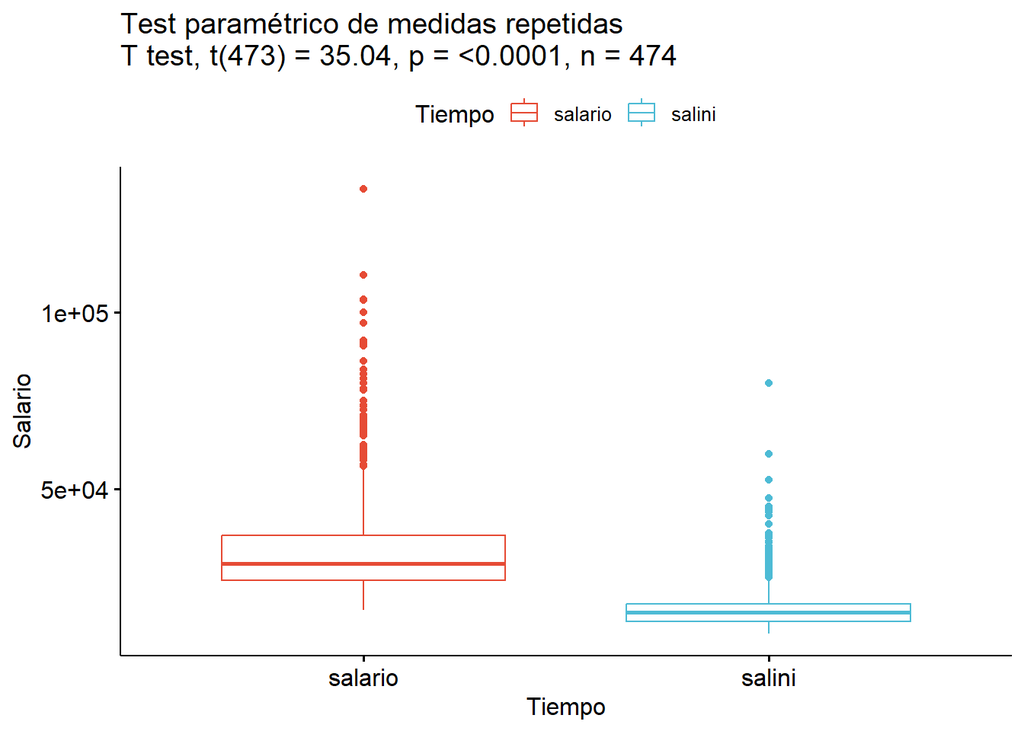

```r
test_t_mr <- t_test(formula = formula.mr.sin.error,
                    data = datos.mr.long, paired = TRUE)
GraficoCajasTest(datos.mr.long, v.depend.mr, v.factor.mr,
                 es_param = TRUE, es_mr = TRUE, test_t_mr)
```

Para comprobar la hipótesis de normalidad basta con calcular la columna formada por las diferencias de las dos muestras pareadas (ambas tienen el mismo tamaño) y aplicar el test de Shapiro o ver el gráfico QQ. Podemos usar las columnas que habíamos construido (`col.salario.inicial` y `col.salario.final`) o bien creamos unas nuevas con los nombres genéricos que hemos introducido anteriormente:

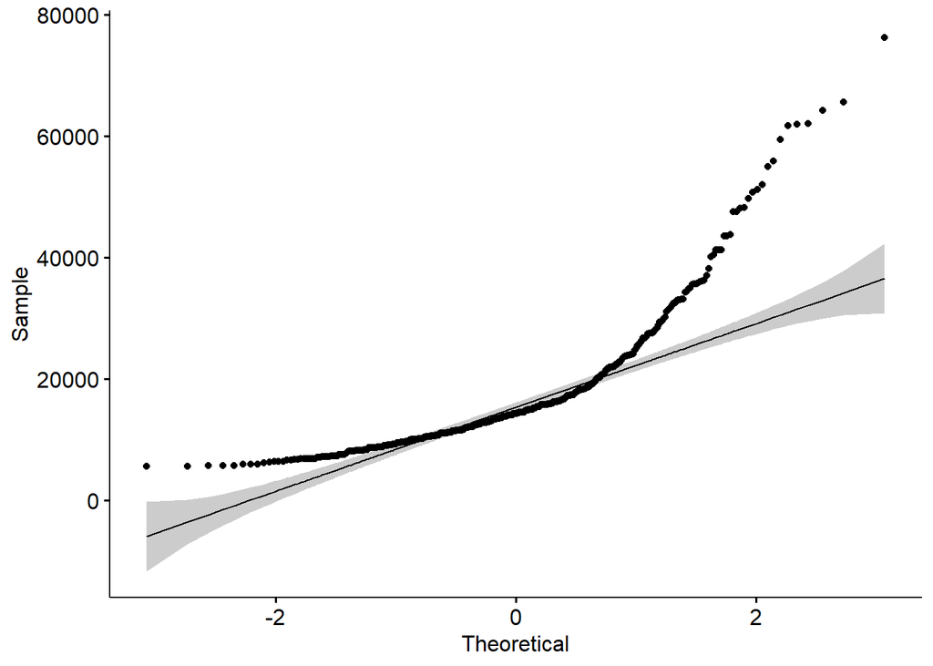

```r
col.mr.1 = datos.mr.wide[,columnas.mr[1]]
col.mr.2 = datos.mr.wide[,columnas.mr[2]]
shapiro.test(x = col.mr.1 - col.mr.2)
##
##  Shapiro-Wilk normality test
##
## data:  col.mr.1 - col.mr.2
## W = 0.78168, p-value < 2.2e-16
ggqqplot(col.mr.1 - col.mr.2)
```

Podemos apreciar que hay una desviación bastante notable de la normalidad por lo que será preferible aplicar un test no paramétrico.

*Nota*. También podríamos haber analizado los residuos: esto se verá posteriormente, cuando veamos el ANOVA general para medidas repetidas.

### 2.2.2 Test no paramétrico para comparar dos muestras dependientes (medidas repetidas)

- test: ¿Puede considerarse que la diferencia entre las **medianas** del salario inicial y el salario final es cero?

En el caso no paramétrico, debemos lanzar el test de Wilcoxon (**Wilcoxon signed-rank test**). Para ello, llamamos a la función `wilcox_test` de `rstatix`. Le pasamos la misma fórmula que habíamos usado en el test t de 2 muestras con medidas repetidas e incluimos el parámetro `paired = TRUE`:

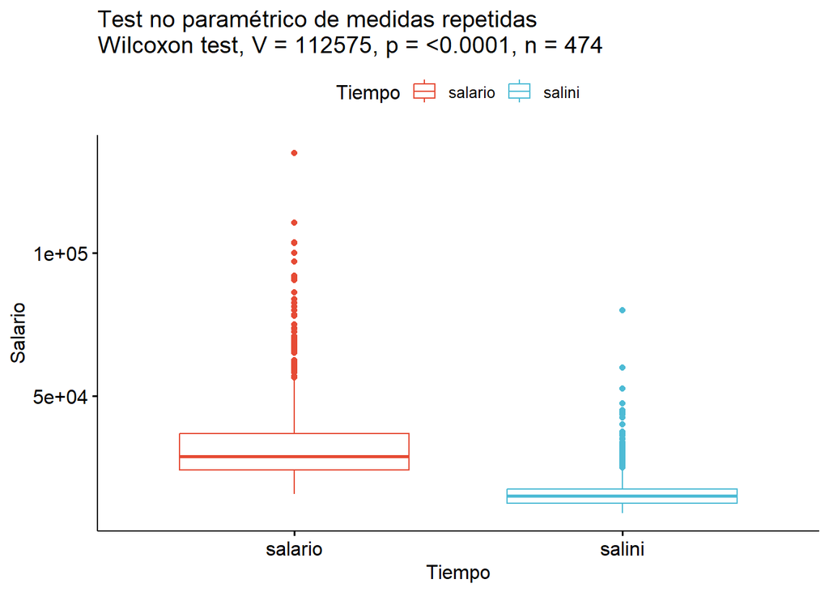

```r
formula.mr.sin.error
## Salario ~ Tiempo
test_wilcoxon_mr = wilcox_test(formula.mr.sin.error, data = datos.mr.long,
                               paired = TRUE)
GraficoCajasTest(datos.mr.long, v.depend.mr, v.factor.mr,
                 es_param = FALSE, es_mr = TRUE ,
                 test_wilcoxon_mr)
```

Para poder asegurar que el test de Wilcoxon es fiable necesitamos comprobar el requisito de que las diferencias se distribuyen de forma simétrica con respecto a la mediana.

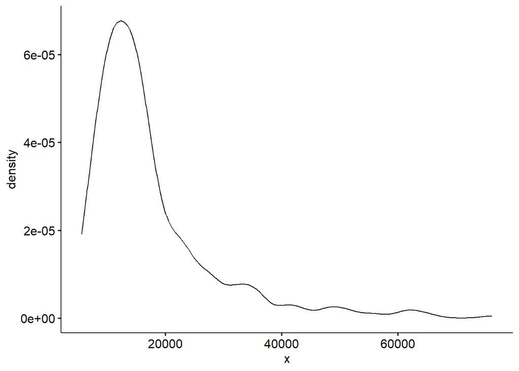

```r
diferencias = col.mr.1 - col.mr.2
ggdensity(data = diferencias)
```

```r
median(diferencias)
## [1] 14250
```

Vemos que no es una distribución simétrica, por lo que procedemos a aplicar el **sign-test** aplicando la función `sign_test` de `rstatix`. El sign-test sólo tiene en cuenta si un valor es mayor que otro, pero no cuánto más, por lo que pierde información y tiene menos potencia que el test de Wilcoxon.

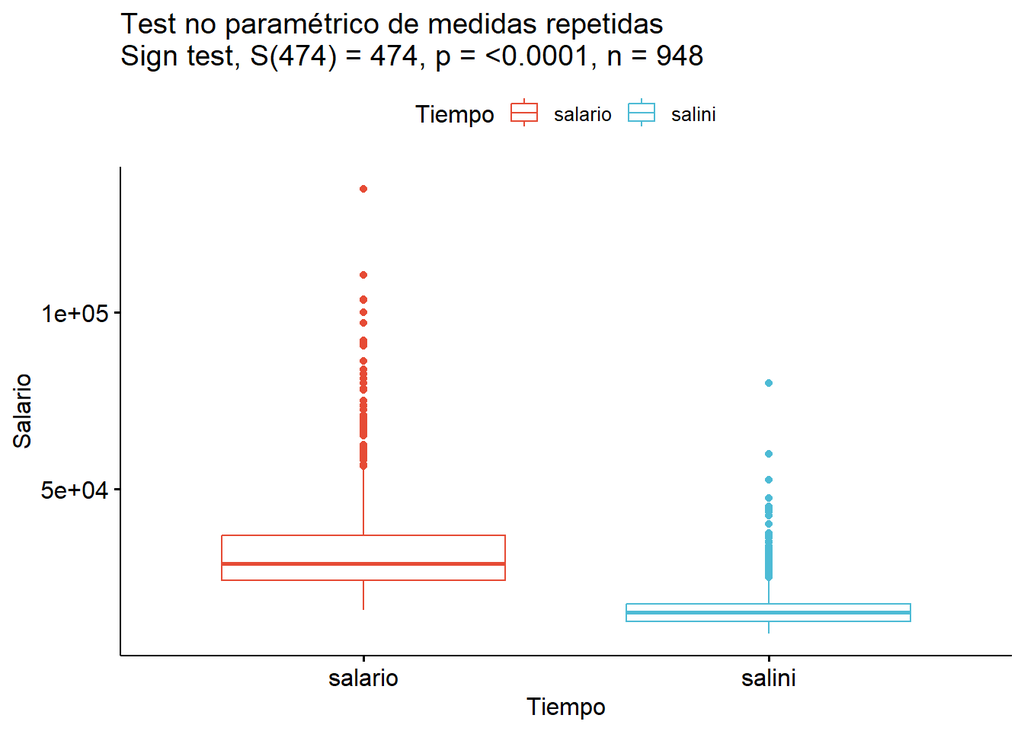

```r
test_sign_mr = sign_test(formula.mr.sin.error, data = datos.mr.long)

GraficoCajasTest(datos.mr.long, v.depend.mr, v.factor.mr,
                 es_param = FALSE, es_mr = TRUE ,
                 test_sign_mr)
```

Por lo tanto, a pesar de haber tenido que aplicar el sign-test que es menos potente que el de Wilcoxon, podemos concluir que las medianas son distintas y por tanto el salario mediano inicial es menor que el salario mediano final. Formalmente, para poder concluir cuál es mayor que la otra, deberíamos haber aplicado un test a una cola (one-sided test) Para ello habría que seleccionar la opción `alternative = "greater"` en la función `wilcox_test` (o en la función `sign_test`).

### 2.2.3 Anova para k muestras dependientes (test paramétrico de medidas repetidas)

Trabajamos con el conjunto de datos Cholesterol.RData. Los datos vienen en formato *wide* por lo que tendrá que transformarlos en *long*. Tenga en cuenta que el nombre del dataset es `Cholesterol`, el vector de columnas de medidas repetidas es `c("Before", "After4weeks", "After8weeks")`, el nombre de la nueva variable dependiente puede ser `NivelColesterol`, el nombre de la nueva variable factor puede ser `Tiempo` y el nombre de la columna de identificador es `ID`.

```r
load("Cholesterol.RData")
datos.mr.wide = Cholesterol
nombres.columnas = colnames(datos.mr.wide)
v.id.mr = nombres.columnas[1]  # El identific. es la primera columna
v.depend.mr = "NivelColesterol"
v.factor.mr = "Tiempo"
columnas.mr = nombres.columnas[-1]  # El resto de columnas son las MR

datos.mr.long = pivot_longer(datos.mr.wide,
                             cols = any_of(columnas.mr),
                             names_to = v.factor.mr,
                             values_to = v.depend.mr)

indice.col.id.mr = which(colnames(datos.mr.long) == v.id.mr)
indice.col.factor.mr = which(colnames(datos.mr.long) == v.factor.mr)
datos.mr.long[,indice.col.id.mr] = as.factor(as.data.frame(datos.mr.long)[,indice.col.id.mr])
datos.mr.long[,indice.col.factor.mr] =as.factor(as.data.frame(datos.mr.long)[,indice.col.factor.mr])

formula.mr.sin.error = as.formula(paste0(v.depend.mr, "~", v.factor.mr))
```

Obtenemos los siguientes datos (mostramos como quedarían las dos primeras filas:

```r
datos.mr.wide[c(1:2),]
##   ID Before After4weeks After8weeks
## 1  1   6.42        5.83        5.75
## 2  2   6.76        6.20        6.13
datos.mr.long[c(1:6),]
## # A tibble: 6 × 3
##   ID    Tiempo      NivelColesterol
##   <fct> <fct>                 <dbl>
## 1 1     Before                 6.42
## 2 1     After4weeks            5.83
## 3 1     After8weeks            5.75
## 4 2     Before                 6.76
## 5 2     After4weeks            6.2
## 6 2     After8weeks            6.13
```

#### 2.2.3.1 Test conjunto (omnibus)

Para contemplar el caso de k grupos de **medidas repetidas**, tenemos que tabajar con la función `anova_test` y con la siguiente fórmula

```r
formula.anova.mr.error = NivelColesterol ~ Tiempo + Error(ID / Tiempo)
```

Para poder utilizar los nombres genéricos que hemos introducido en los apartados anteriores, usamos la siguiente expresión general:

```r
formula.anova.mr.error = as.formula(paste0(v.depend.mr, "~",
                                    v.factor.mr, "+ Error(" ,
                                    v.id.mr , "/" , v.factor.mr , ")"))
formula.anova.mr.error
## NivelColesterol ~ Tiempo + Error(ID/Tiempo)
```

Ahora ya estamos en condiciones de aplicar la función `anova_test` de `rstatix`. Dicha función analiza el formato de la fórmula y al encontrar el término `Error` aplica automáticamente un ANOVA de medidas repetidas:

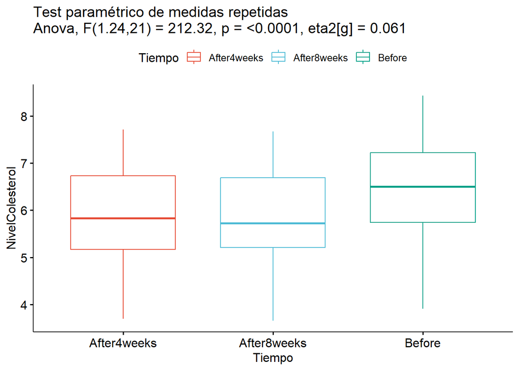

```r
test_anova_mr <- anova_test(formula = formula.anova.mr.error,
                            data = datos.mr.long)
GraficoCajasTest(datos.mr.long, v.depend.mr, v.factor.mr,
                 es_param = TRUE, es_mr = TRUE, test_anova_mr)
```

Debemos señalar que la función `anova_test` automáticamente aplica el test de **Mauchly** para comprobar la hipótesis de esfericidad y en el caso de que no se cumpla, aplica también automáticamente la corrección de **Greenhouse-Geisser**

Como ejercicio, escriba la fórmula correspondiente al ejemplo de los datos de los empleados y lance la función `anova_test`. El resultado es equivalente al que obtuvimos en el apartado test para dos muestras dependientes con la función `t_test` (puede comprobar que el valor de F obtenido en el ANOVA es el cuadrado de la t)

Para ver la normalidad de los residuos, definimos la siguiente función que extrae los residuos del modelo. Al igual que vimos en el apartado Prueba para dos muestras independientes (test paramétrico), usamos una función similar (hemos definido `ResiduosMR` usando la función `anova_test` de `rstatix`)

```r
ResiduosMR = function(data.long, var.depend.mr, var.factor.mr, var.id.mr, columnas.mr){
  formula.anova.mr.error = as.formula(paste0(var.depend.mr, "~",
                                    var.factor.mr, "+ Error(" ,
                                    var.id.mr , "/" , var.factor.mr , ")"))
  test_anova_mr = anova_test(formula.anova.mr.error, data = data.long)
  residuos_anova_test_mr = residuals(attr(test_anova_mr, "args")$model)
  # Me da los residuos por cada columna, por lo que hay que agregarlos todos:
  residuos.juntos.mr = pivot_longer(as.data.frame(residuos_anova_test_mr),
                                    cols = any_of(columnas.mr))
  residuos.juntos.mr  = residuos.juntos.mr$value
}
```

Llamamos a la función y mostramos los residuos:

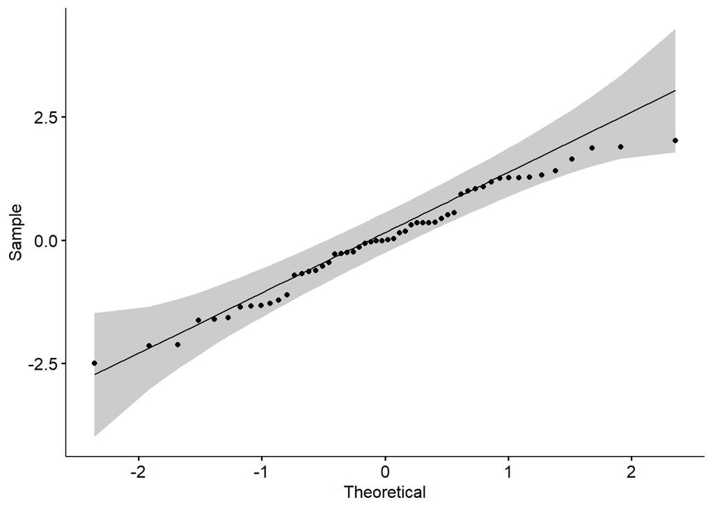

```r
formula.anova.mr.error
## NivelColesterol ~ Tiempo + Error(ID/Tiempo)
residuos.mr = ResiduosMR(datos.mr.long, v.depend.mr, v.factor.mr,
                         v.id.mr, columnas.mr)
ggqqplot(residuos.mr)
```

Podemos apreciar que los residuos se ajustan a una normal, por lo que se cumplen las hipótesis del test paramétrico (realmente no se cumplía el requisito de esfericidad pero el test lo solventa automáticamente aplicando la corrección sobre los grados de libertad de Greenhouse-Geisser) Por tanto podemos concluir que existe al menos un grupo con una media distinta de los otros grupos: en nuestro ejemplo, el nivel de colesterol al inicio del estudio es mayor que el nivel medido después de 4 y 8 semanas de tratamiento. A continuación, procedemos a ejecutar el post-hoc para corroborar la anterior afirmación y para comprobar si hay diferencias significativas entre el nivel de colesterol medido a las 4 y a las 8 semanas.

#### 2.2.3.2 Post hoc

##### Post hoc específico

Para lanzar un test específico de comparaciones múltiples como el de Tukey, tendríamos que recurrir a otros paquetes y ajustar otros modelos que se escapan del nivel de este guion. Para más información, puede consultar:

https://stackoverflow.com/questions/74839746/anova-with-repeated-measures-and-tukeyhsd-post-hoc-test-in-r

##### Post hoc genérico

Para lanzar las comparaciones múltiples con un test genérico y una penalización del nivel de significación (por ejemplo, Holm) usamos la función `pairwise_t_test` de `rstatix` (es un wrapper de `pairwise.t.test`). Es muy importante que observe que se lanza con la misma fórmula que habíamos usado en el caso de 2 muestras dependientes y no la fórmula que contenía el término del error. También incluimos el parámetro `paired = TRUE`:

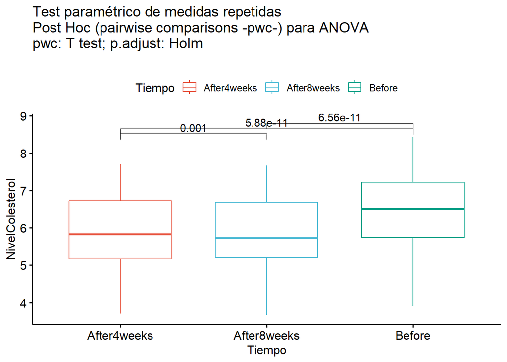

```r
formula.mr.sin.error = as.formula(paste0(v.depend.mr, "~", v.factor.mr))
formula.mr.sin.error
## NivelColesterol ~ Tiempo

post_pw_t_test_mr = pairwise_t_test(formula.mr.sin.error,
                                    data = datos.mr.long,
                                    paired = TRUE,
                                    p.adjust.method = "holm")
GraficoCajasPost(datos.mr.long, v.depend.mr, v.factor.mr,
                 es_param = TRUE , es_mr = TRUE,
                 post_pw_t_test_mr)
```

El resultado del test nos dice que también hay diferencias significativas entre el primer y segundo grupo (medición después de 4 y 8 semanas) Si lanzamos el mismo test planteando como hipótesis alternativa “la media de un grupo es mayor o igual que la del otro grupo” (opción `alternative = "greater"` de la función `pairwise_t_test`), obtendríamos una significación de 0.002 entre los dos primeros grupos (sigue siendo significativa) En definitiva, podemos concluir que gracias al tratamiento se aprecia una bajada del nivel de colesterol muy acusada en las 4 primeras semanas y otra bajada, mucho menor pero significativa, entre la cuarta y octava semana.

##### Post hoc con control

Si queremos fijar un grupo de control, podemos llamar a la misma función anterior `pairwise_t_test`, indicándolo en el parámetro `ref.group`

### 2.2.4 Anova para k muestras dependientes (test no paramétrico de medidas repetidas)

Aplicaremos este tipo de tests cuando no se de el requisito de normalidad del caso paramétrico o cuando los datos sean ordinales, como es el caso del ejemplo sobre preferencias comerciales que vimos en la sección de Jamovi: Friedman. Vamos a trabajar con este conjunto de datos. La versión en R la puede descargar del siguiente enlace:

[Preferencias comerciales (RData)](https://decsai.ugr.es/jccubero/Master/CommercialRatings.RData)

Establecemos los nombres de las variables y realizamos la transformación al formato *long*:

```r
load("CommercialRatings.RData")
datos.mr.wide = CommercialRatings
nombres.columnas = colnames(datos.mr.wide)
v.id.mr = nombres.columnas[1]  # El identific. es la primera columna
v.depend.mr = "Valoracion"
v.factor.mr = "Marca"
columnas.mr = nombres.columnas[-1]  # El resto de columnas son las MR

datos.mr.long = pivot_longer(datos.mr.wide,
                             cols = any_of(columnas.mr),
                             names_to = v.factor.mr,
                             values_to = v.depend.mr)

indice.col.id.mr = which(colnames(datos.mr.long) == v.id.mr)
indice.col.factor.mr = which(colnames(datos.mr.long) == v.factor.mr)
datos.mr.long[,indice.col.id.mr] = as.factor(as.data.frame(datos.mr.long)[,indice.col.id.mr])
datos.mr.long[,indice.col.factor.mr] =as.factor(as.data.frame(datos.mr.long)[,indice.col.factor.mr])

datos.mr.wide[c(1:2),]
##   id com_1 com_2 com_3 com_4
## 1  1     2     6     7     6
## 2  2     1     7     7     6

datos.mr.long[c(1:8),]
## # A tibble: 8 × 3
##   id    Marca Valoracion
##   <fct> <fct>      <int>
## 1 1     com_1          2
## 2 1     com_2          6
## 3 1     com_3          7
## 4 1     com_4          6
## 5 2     com_1          1
## 6 2     com_2          7
## 7 2     com_3          7
## 8 2     com_4          6
```

#### 2.2.4.1 Test conjunto (omnibus)

El test aplicable en este caso es el de **Friedman**. La fórmula que debemos usar ahora es de la forma:

```r
var.dependiente ~ factor | identificador
## var.dependiente ~ factor | identificador
```

En nuestro caso sería:

```r
Valoracion ~ Marca | id
## Valoracion ~ Marca | id
```

o en general, usando los nombres de las variables que habíamos creado:

```r
formula.anova.friedman_test = as.formula(paste0(v.depend.mr, "~",
                                                v.factor.mr , "|" ,
                                                v.id.mr))
```

Basta llamar a la funcion `friedman_test` de `rstatix`:

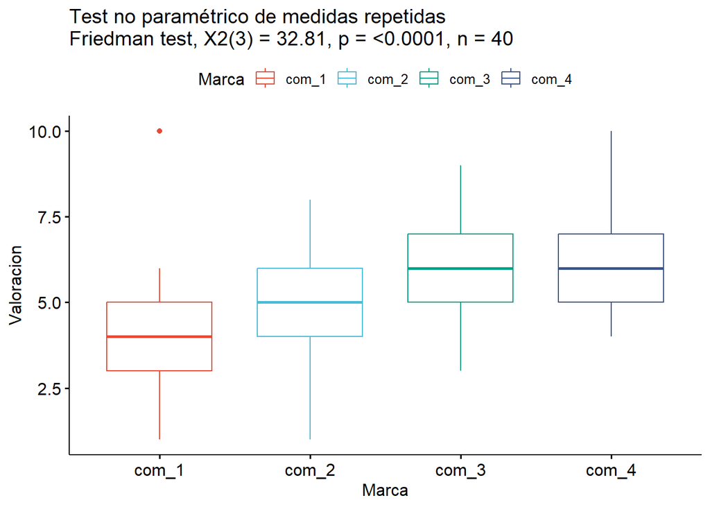

```r
formula.anova.friedman_test
## Valoracion ~ Marca | id

test_friedman = friedman_test (formula.anova.friedman_test,
                               data = datos.mr.long)
GraficoCajasTest(datos.mr.long, v.depend.mr, v.factor.mr,
                 es_param = FALSE, es_mr = TRUE ,
                 test_friedman)
```

Finalmente, para comprobar si todos los grupos tienen distribuciones similares, lanzamos la función `ggdensity`:

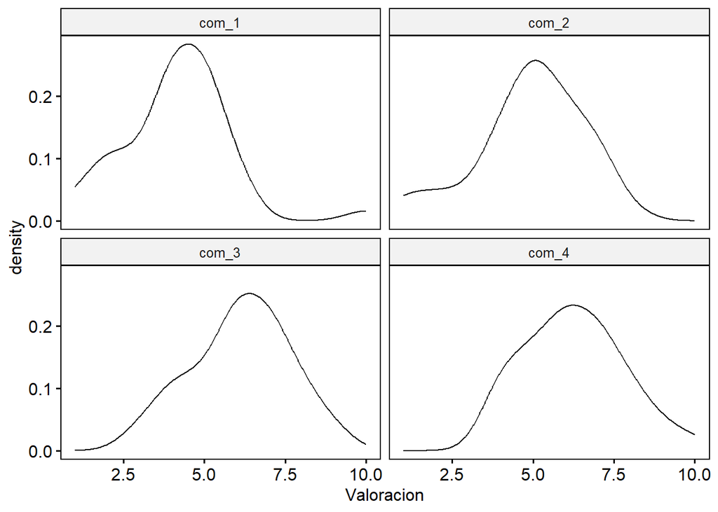

Al tener distribuciones similares, podemos afirmar que el test de Friedman es un test sobre las medianas (en caso contrario sería de dominancia estocástica) Así pues, podemos concluir que hay al menos una marca comercial que tiene una preferencia distinta a las otras marcas.

#### 2.2.4.2 Post hoc

##### Post hoc específico

Jamovi lanza el test de Durbin, pero como ya vimos, no aplica ninguna penalización interna. Lo correcto sería lanzarlo con una corrección como Holm. Para lanzar un test específico de comparaciones múltiples para Friedman, podemos recurrir a los tests incluidos en el paquete `PMCMRPlus` (**Nemenyi**, **Durbin**, etc.) Muchos de los tests de `PMCMRPlus` requieren que se indiquen los siguientes parámetros:

- `y` es un vector con los datos de la variable dependiente
- `groups` es un vector con los datos del factor
- `blocks` es un vector con los datos del identificador

Los vectores anteriores se refieren al conjunto de datos en el formato *long*. Construimos por tanto los siguientes vectores:

```r
col.v.depend.mr = as.data.frame(datos.mr.long)[,v.depend.mr]
col.v.factor.mr = as.data.frame(datos.mr.long)[,v.factor.mr]
col.id.factor.mr = as.data.frame(datos.mr.long)[,v.id.mr]

head(datos.mr.long)
## # A tibble: 6 × 3
##   id    Marca Valoracion
##   <fct> <fct>      <int>
## 1 1     com_1          2
## 2 1     com_2          6
## 3 1     com_3          7
## 4 1     com_4          6
## 5 2     com_1          1
## 6 2     com_2          7

a_mostrar = c(1:6)
col.v.depend.mr[a_mostrar]
## [1] 2 6 7 6 1 7
col.v.factor.mr[a_mostrar]
## [1] com_1 com_2 com_3 com_4 com_1 com_2
## Levels: com_1 com_2 com_3 com_4
col.id.factor.mr[a_mostrar]
## [1] 1 1 1 1 2 2
## 40 Levels: 1 2 5 8 9 10 11 12 14 15 16 17 19 21 22 24 27 28 29 30 31 33 35 36 37 39 40 41 43 ... 59
```

```r
post_frd_durbin_Jamovi <- durbinAllPairsTest(y = col.v.depend.mr ,
                                             groups = col.v.factor.mr,
                                             blocks = col.id.factor.mr,
                                             p.adjust.method = "none")

post_frd_durbin_holm <- durbinAllPairsTest(y = col.v.depend.mr,
                                            groups = col.v.factor.mr,
                                            blocks = col.id.factor.mr,
                                            p.adjust.method = "holm")
post_frd_durbin_Jamovi
##       com_1   com_2  com_3
## com_2 0.0325  -      -
## com_3 2.1e-07 0.0011 -
## com_4 2.1e-07 0.0011 1.0000

post_frd_durbin_holm
##       com_1   com_2  com_3
## com_2 0.0651  -      -
## com_3 1.3e-06 0.0043 -
## com_4 1.3e-06 0.0043 1.0000
```

Vemos que, efectivamente, el test que lanzaba Jamovi ofrece unos valores de significación más bajos, resultado de no haber controlado el error FWER, por lo que no son fiables. Además, el test de Durbin está diseñado para el caso de *bloques incompletos* (*incomplete block design*) por lo que mejor aplicamos un post hoc como el de **Nemenyi** o el test más actual de **Eisinga** (2017), usando la función `frdAllPairsExactTest`:

```r
post_frd_eisinga <- frdAllPairsExactTest(y = col.v.depend.mr ,
                                         groups = col.v.factor.mr,
                                         blocks = col.id.factor.mr,
                                         p.adjust.method = "holm")

post_frd_eisinga
##       com_1   com_2 com_3
## com_2 0.182   -     -
## com_3 4.5e-05 0.032 -
## com_4 4.5e-05 0.032 1.000
```

Podemos apreciar que hay dos grupos, el formado por `{com_1, com_2}` y otro formado por `{com_3, com_4}`. Tanto `com_1` como `com_2` son marcas con una menor preferencia por parte de los clientes que cualquiera de las marcas `com_3` y `com_4`.

##### Post hoc genérico

El post hoc usando un test genérico con penalización lo hacemos de una forma análoga al caso paramétrico. En ese caso, habíamos usado la fórmula básica sin término de error y la función `pairwise_t_test`. Ahora usamos una fórmula análoga y la función `pairwise_wilcox_test` que aplica el test no paramétrico para 2 muestras pareadas de Wilcoxon (**Wilcoxon signed rank test**) a todos los pares. Debemos pasar como parámetro `paired = TRUE`. Por defecto usa la penalización de Holm:

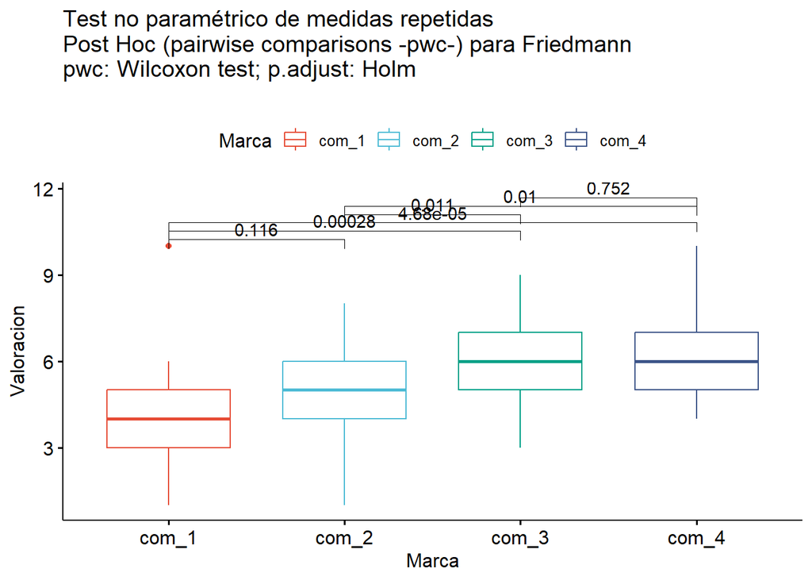

```r
formula.mr.sin.error = as.formula(paste0(v.depend.mr, "~", v.factor.mr))
formula.mr.sin.error
## Valoracion ~ Marca

post_pairwise_wilcox_test_mr = pairwise_wilcox_test(formula.mr.sin.error,
                                     data = datos.mr.long,
                                     paired = TRUE)
GraficoCajasPost(datos.mr.long, v.depend.mr, v.factor.mr,
                 es_param =  FALSE, es_mr = TRUE, post_pairwise_wilcox_test_mr)
```

*Nota*. También se puede usar la función `wilcox_test`. Esta función realiza automáticamente las comparaciones múltiples cuando ve que el factor tiene más de un valor.

De nuevo, podemos apreciar que se distinguen los mismos grupos con medias distintas: el formado por `{com_1, com_2}` y el formado por `{com_3, com_4}`.

En cualquier caso, para poder aplicar cada una de las comparaciones múltiples con el *Wilcoxon signed rank test* deberíamos confirmar que las distribuciones de todas las diferencias son simétricas. Para ello, podemos construir todas las posibles combinaciones de las columnas con `CombPairs` y realizar un plot de las densidades de dichas diferencias:

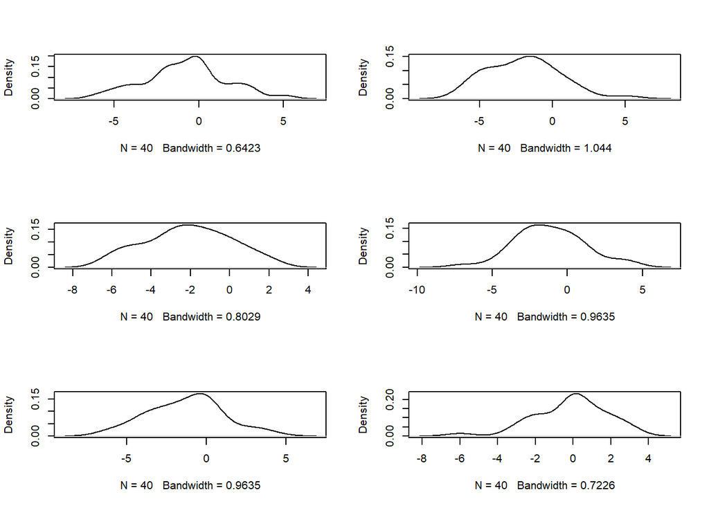

```r
comb = CombPairs(columnas.mr)
comb
##      X1    X2
## 1 com_1 com_2
## 2 com_1 com_3
## 3 com_1 com_4
## 4 com_2 com_3
## 5 com_2 com_4
## 6 com_3 com_4

par(mfrow=c(3, 2))
sapply(c(1:nrow(comb)) ,
       function(x) plot (density(datos.mr.wide[comb[x,1]][,1] -  datos.mr.wide[comb[x,2]][,1]) , main = ""))
```

Es aceptable admitir que todas las anteriores distribuciones son simétricas, por lo que el post-hoc genérico también encuentra significativa la diferencia entre los grupos `{com_1, com_2}` y `{com_3, com_4}`.

##### Post hoc con control

También podemos seleccionar un **control**, fijando un grupo y comparando el resto con él. Para ello, podemos usar la función `frdManyOneExactTest` que implementa el post hoc con control de Eisinga (también está disponible el de Nemenyi a través de la función `frdManyOneNemenyiTest`)

**IMPORTANTE**: El control se establece según el orden lexicográfico entre los nombres de las columnas.

```r
post_frd_eisinga_control = frdManyOneExactTest(y = col.v.depend.mr ,
                                               groups = col.v.factor.mr,
                                               blocks = col.id.factor.mr,
                                               p.adjust.method = "holm")
post_frd_eisinga_control
##       com_1
## com_2 0.091
## com_3 2.3e-05
## com_4 2.3e-05
```

Podemos ver que, al haber fijado un grupo de control y disminuir el número de comparaciones, hemos rebajado el p-value de la comparación entre `com_1` y `com_2` de 0.182 a 0.091, aunque no lo suficiente como para que sea significativo.

## 2.3 Test para comparar resultados de varios clasificadores

Vamos a aplicar lo visto anteriormente al conjunto de datos de clasificación. El fichero `RData` lo puede descargar desde este enlace:

[Classification Algorithms (RData)](https://decsai.ugr.es/jccubero/Master/ClassificationAlgorithms.RData)

Vamos a suponer que queremos comparar el algoritmo 3 con el resto. Tal y como hemos visto en la sección anterior, debemos garantizar que el grupo de control tenga el nombre en la posición más baja según un orden lexicográfico. Por tanto, lo que vamos a hacer es anteponerle un símbolo `_`:

```r
load("ClassificationAlgorithms.RData")
datos.mr.wide = ClassificationAlgorithms
nombres.columnas = colnames(datos.mr.wide)
v.id.mr = nombres.columnas[1]
v.depend.mr = "TasaAcierto"
v.factor.mr = "Algoritmo"
grupo.control.mr = "Alg3"
indice.control = match(grupo.control.mr, nombres.columnas)
colnames(datos.mr.wide)[indice.control] = paste0("_", grupo.control.mr)
nombres.columnas = colnames(datos.mr.wide)
```

Para realizar la transformación al formato `long` le asignamos a `columnas.mr` todas las columnas menos la primera (la de índice 1) ya que contiene el nombre del dataset y no es una medida repetida. También vamos a suprimir del análisis el algoritmo 1 (columna con índice 2) ya que presenta un comportamiento sistemáticamente peor que el resto y no queremos que la razón de que el test de Friedman resulte significativo sea porque hemos incluido dicho algoritmo en el estudio (que por supuesto va a tener una mediana mucho menor que el resto)

```r
columnas.mr = nombres.columnas[-c(1,2)]
```

Realizamos la transformación de los datos al formato `long` y establecemos los nombres de las variables:

```r
datos.mr.long = pivot_longer(datos.mr.wide,
                             cols = any_of(columnas.mr),
                             names_to = v.factor.mr,
                             values_to = v.depend.mr)

head(datos.mr.long)
## # A tibble: 6 × 4
##   Dataset  Alg1 Algoritmo TasaAcierto
##   <chr>   <dbl> <chr>           <dbl>
## 1 aud      25.3 Alg2             76
## 2 aud      25.3 _Alg3            75
## 3 aud      25.3 Alg4             69.6
## 4 aud      25.3 Alg5             71
## 5 aud      25.3 Alg6             70.9
## 6 aud      25.3 Alg7             57.7

indice.col.id.mr = which(colnames(datos.mr.long) == v.id.mr)
indice.col.factor.mr = which(colnames(datos.mr.long) == v.factor.mr)
datos.mr.long[,indice.col.id.mr] = as.factor(as.data.frame(datos.mr.long)[,indice.col.id.mr])
datos.mr.long[,indice.col.factor.mr] =as.factor(as.data.frame(datos.mr.long)[,indice.col.factor.mr])

col.v.depend.mr = as.data.frame(datos.mr.long)[,v.depend.mr]
col.v.factor.mr = as.data.frame(datos.mr.long)[,v.factor.mr]
col.id.factor.mr = as.data.frame(datos.mr.long)[,v.id.mr]
```

Comprobamos la normalidad de los residuos, una vez que hemos eliminado el Algoritmo 1. Recuerde que teníamos que establecer la fórmula `formula.anova.mr.error` y llamar a la función `ResiduosMR`:

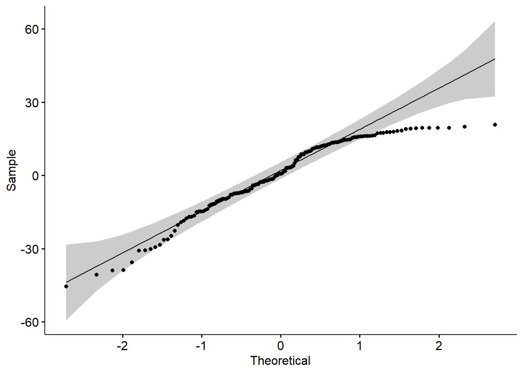

```r
formula.anova.mr.error = as.formula(paste0(v.depend.mr, "~",
                                    v.factor.mr, "+ Error(" ,
                                    v.id.mr , "/" , v.factor.mr , ")"))
formula.anova.mr.error
## TasaAcierto ~ Algoritmo + Error(Dataset/Algoritmo)

residuos.mr = ResiduosMR(datos.mr.long, v.depend.mr, v.factor.mr,
                         v.id.mr, columnas.mr)
ggqqplot(residuos.mr)
```

Realmente, los residuos no se alejan demasiado de una distribución normal. Sin embargo, si lanzamos el test de Shapiro, obtenemos que se rechaza la normalidad:

```r
shapiro.test(residuos.mr)
##
##  Shapiro-Wilk normality test
##
## data:  residuos.mr
## W = 0.93373, p-value = 1.821e-06
```

Por tanto, si queremos ser rigurosos, en vez de lanzar un ANOVA paramétrico de medidas repetidas, debemos lanzar un test no paramétrico (de Friedman). Por lo tanto, debemos establecer la fórmula pertinente para ejecutar la función `friedman_test`:

```r
formula.anova.friedman_test = as.formula(paste0(v.depend.mr, "~",
                                                v.factor.mr , "|" ,
                                                v.id.mr))
formula.anova.friedman_test
## TasaAcierto ~ Algoritmo | Dataset
```

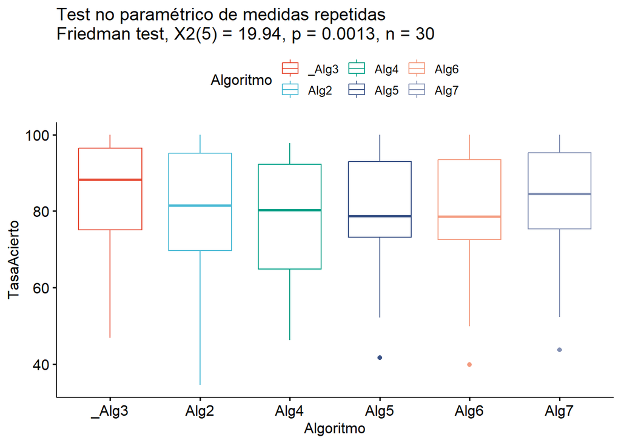

```r
test_friedman = friedman_test (formula.anova.friedman_test,
                               data = datos.mr.long)
GraficoCajasTest(datos.mr.long, v.depend.mr, v.factor.mr,
                 es_param = FALSE, es_mr = TRUE ,
                 test_friedman)
```

Podemos apreciar que el test resulta significativo. Aceptamos por tanto que hay al menos un algoritmo con un comportamiento distinto. Lanzamos el post hoc, aplicando el test de **Eisinga**, usando la función `frdAllPairsExactTest` de `PMCMRPlus` (puede probar también con el test de **Nemenyi** usando la función `frdAllPairsNemenyiTest`):

```r
post_frd_eisinga <- frdAllPairsExactTest(y = col.v.depend.mr ,
                                         groups = col.v.factor.mr,
                                         blocks = col.id.factor.mr)
post_frd_eisinga
##      _Alg3 Alg2  Alg4  Alg5  Alg6
## Alg2 0.032 -     -     -     -
## Alg4 0.073 1.000 -     -     -
## Alg5 0.023 1.000 1.000 -     -
## Alg6 0.023 1.000 1.000 1.000 -
## Alg7 1.000 0.220 0.391 0.185 0.185
```

```r
post_frd_eisinga_control = frdManyOneExactTest(y = col.v.depend.mr ,
                                               groups = col.v.factor.mr,
                                               blocks = col.id.factor.mr,
                                               p.adjust.method = "holm")
post_frd_eisinga_control
##      _Alg3
## Alg2 0.0075
## Alg4 0.0121
## Alg5 0.0075
## Alg6 0.0075
## Alg7 0.4702
```

por lo que concluimos que el algoritmo 3 no se puede diferenciar del 7 pero sí del resto. Finalmente, vamos a ver la distribución de las variables de medidas repetidas (los algoritmos):

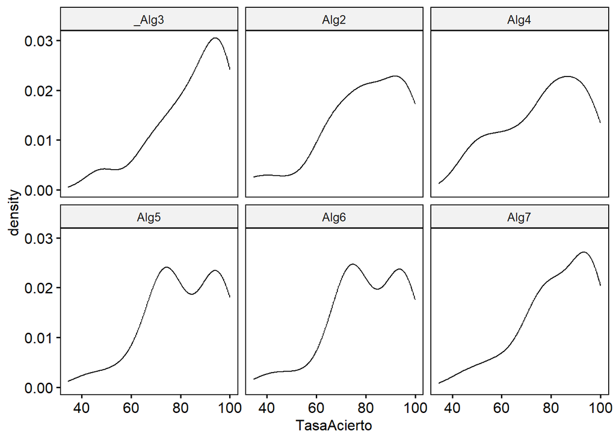

```r
ggdensity(as.data.frame(datos.mr.long), v.depend.mr, facet.by = v.factor.mr)
```

Los algoritmos 2, 3, 4 y 7 tienen distribuciones similares, pero algo distintas a los algoritmos 5 y 6. Por lo tanto, no podemos extraer conclusiones con rigor estadístico sobre las medianas y el test de Friedman sería un test de dominancia estocástica.